# R Notebook

```r
library(tidyverse)
library(infer)
library(janitor)
```

```r
ames_houses <- read_csv("ames.csv") %>% clean_names()
```

# Q1 - We are going to use a dataset on house sales in Ames, Iowa over a number of years. We will be interested in the SalePrice of houses (though we should clean_names() the data, so this will end up as sale_price). Load the data and explore it.

```r
skimr::skim(ames_houses)
```

```
-- Data Summary ------------------------
                           Values
Name                       ames_houses
Number of rows             2930
Number of columns          82
_______________________
Column type frequency:
  character                43
  numeric                  39
________________________
Group variables            None
```

|  | skim_variable | n_missing | complete_rate | min | max | empty | n_unique | whitespace |
| --- | --- | --- | --- | --- | --- | --- | --- | --- |
| 1 | ms_zoning | 0 | 1.00000000 | 2 | 7 | 0 | 7 | 0 |
| 2 | street | 0 | 1.00000000 | 4 | 4 | 0 | 2 | 0 |
| 3 | alley | 2732 | 0.06757679 | 4 | 4 | 0 | 2 | 0 |
| 4 | lot_shape | 0 | 1.00000000 | 3 | 3 | 0 | 4 | 0 |
| 5 | land_contour | 0 | 1.00000000 | 3 | 3 | 0 | 4 | 0 |
| 6 | utilities | 0 | 1.00000000 | 6 | 6 | 0 | 3 | 0 |
| 7 | lot_config | 0 | 1.00000000 | 3 | 7 | 0 | 5 | 0 |
| 8 | land_slope | 0 | 1.00000000 | 3 | 3 | 0 | 3 | 0 |
| 9 | neighborhood | 0 | 1.00000000 | 5 | 7 | 0 | 28 | 0 |
| 10 | condition_1 | 0 | 1.00000000 | 4 | 6 | 0 | 9 | 0 |

[output cut: 33 more lines]

|  | skim_variable | n_missing | complete_rate | mean | sd | p0 | p25 | p50 | p75 | p100 | hist |
| --- | --- | --- | --- | --- | --- | --- | --- | --- | --- | --- | --- |
| 1 | order | 0 | 1.0000000 | 1465.50000000 | 845.9624696 | 1 | 733.25 | 1465.5 | 2197.75 | 2930 |  |
| 2 | pid | 0 | 1.0000000 | 714464496.98873723 | 188730844.6493901 | 526301100 | 528477022.50 | 535453620.0 | 907181097.50 | 1007100110 |  |
| 3 | ms_sub_class | 0 | 1.0000000 | 57.38737201 | 42.6380246 | 20 | 20.00 | 50.0 | 70.00 | 190 |  |
| 4 | lot_frontage | 490 | 0.8327645 | 69.22459016 | 23.3653350 | 21 | 58.00 | 68.0 | 80.00 | 313 |  |
| 5 | lot_area | 0 | 1.0000000 | 10147.92184300 | 7880.0177594 | 1300 | 7440.25 | 9436.5 | 11555.25 | 215245 |  |
| 6 | overall_qual | 0 | 1.0000000 | 6.09488055 | 1.4110261 | 1 | 5.00 | 6.0 | 7.00 | 10 |  |
| 7 | overall_cond | 0 | 1.0000000 | 5.56313993 | 1.1115366 | 1 | 5.00 | 5.0 | 6.00 | 9 |  |
| 8 | year_built | 0 | 1.0000000 | 1971.35631399 | 30.2453606 | 1872 | 1954.00 | 1973.0 | 2001.00 | 2010 |  |
| 9 | year_remod_add | 0 | 1.0000000 | 1984.26655290 | 20.8602859 | 1950 | 1965.00 | 1993.0 | 2004.00 | 2010 |  |
| 10 | mas_vnr_area | 23 | 0.9921502 | 101.89680083 | 179.1126106 | 0 | 0.00 | 0.0 | 164.00 | 1600 |  |

[output cut: 29 more lines]

Q2 - Plot a histogram of sale_price. Is the distribution normal?

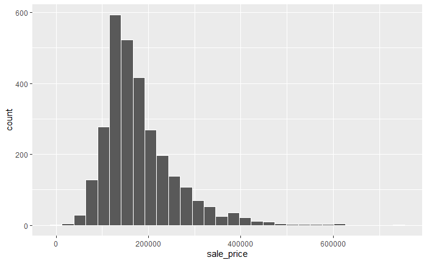

# Q3 - Calculate the population parameter mean of sale_price. Store it in a variable, as we’ll need this value later when we check if each CI contains the parameter value or not.

```r
pop_para <- ames_houses %>%
  summarise(mean_sale_price = mean(sale_price))
```

# Q4 - Now we are going to: - take 1000 random samples each of size 100 from sale_price in ames - create a boostrap sampling distribution of mean(sale_price) from each 100-observation sample (use 1000 reps) - calculate the 95% CI for each bootstrap distribution - store the upper and lower bounds of the CI in a tibble called results

Use the infer workflow to generate the bootstrap distributions and CIs. This code will be pretty hard to write. Think about wrapping the sample creation and infer code in a for loop to generate 1000 random samples and CIs. Create an empty results tibble before the loop, and bind_rows() to it every time you generate a new set of CI bounds.

There’s an outline of the code below, and the full solution below that (if you get stuck). Have a go, but don’t spend too long on this, it’s more important to spend your time thinking about CIs!

```r
results <- tibble()
for(sample_num in 1:1000){
  this_sample <- ames_houses %>%
    rep_sample_n(size = 100, reps = 1) %>%
    ungroup() %>%
    select(sale_price)

  this_bootstrap <- this_sample %>%
    specify(response = sale_price) %>%
    generate(reps = 1000, type = "bootstrap") %>%
    calculate(stat = "mean")

  this_ci <- this_bootstrap %>%
    get_ci(level = 0.95, type = "percentile")

  this_result <- c(
    sample_num = sample_num,
    lower = this_ci %>%
      pull(lower_ci),
    upper = this_ci %>%
      pull(upper_ci)
  )
  results <- results %>%
    bind_rows(this_result)
}
```